# DS4SI-final

Group H

12/05/2020

```r
# the data files are too large to be put in the repository, specify your own data repository
# data_file_path <- "/Users/michaelfive/Google Drive/PISA/Task Flow/replication15feb"
#
# ## load in PISA 2015 data
# dat <- read.spss(file.path(data_file_path, "CY6_MS_CMB_STU_QQQ.sav"), to.data.frame=T)
#
# # load in GGI 2015 data
# cdat <- read.csv(file.path(data_file_path,"GGI2015.csv"), as.is = T)

load("~/Desktop/R Directory/Git learning/DS4SI-final.RData")
```

```r
# functions to calculate cohen's d
cohens_d <- function(x, y) {
  lx <- length(x)- 1
  ly <- length(y)- 1
  md  <- mean(x, na.rm = T) - mean(y, na.rm = T)        ## mean difference (numerator)
  csd <- lx * var(x,na.rm = T) + ly * var(y,na.rm = T)
  csd <- csd/(lx + ly)
  csd <- sqrt(csd)                     ## common sd computation

  cd  <- md/csd                        ## cohen's d
  return(cd)
}
```

# Replication: PISA & GGGI

We replicate here all the analysis in the original study that used the PISA 2015 data and the GGGI 2015 data.

```r
## select relevant variables and countries from the data set

dat.s <- dat %>% select(CNTRYID,W_FSTUWT,ST004D01T, SCIEEFF,PV1MATH:PV10SCIE)
names(dat.s)[c(1:4)] <- c("country","weight","gender", "efficacy")

# turn factor into numeric
dat.s$efficacy <- as.numeric(as.character(dat.s$efficacy))

dat.s <- dat.s[!dat.s$country %in% c(
  "Chinese Taipei","Puerto Rico",
  "Dominican Republic", "Kosovo",
  "USA (Massachusetts)", "USA (North Carolina)",
  "Argentina (Ciudad Autónoma de Buenos)",
  "Spain (Regions)","Spain (Regions)_duplicated_971") ,  ]

## calculation of the intraindividual scores

cat("Step 1: We standardized the mathematics, science, and reading scores on a nation-by-nation basis. We call these new standardized scores zMath, zRead- ing, and zScience, respectively.")
```

Step 1: We standardized the mathematics, science, and reading scores on a nation-by-nation basis. We call these new standardized scores zMath, zRead- ing, and zScience, respectively.

```r
dat.s$scie <- rowMeans(dat.s[,paste("PV",1:5,"SCIE",sep="")])
dat.s$math <- rowMeans(dat.s[,paste("PV",1:5,"MATH",sep="")])
dat.s$read <- rowMeans(dat.s[,paste("PV",1:5,"READ",sep="")])

dat.s <- dat.s %>% group_by(country) %>% mutate(
  z_scie = stdz(scie, weight),
  z_math = stdz(math, weight),
  z_read = stdz(read, weight)
)

cat("Step 2: We standardized the mathematics, science, and reading scores on a nation-by-nation basis. We call these new standardized scores zMath, zReading, and zScience, respectively.")
```

Step 2: We standardized the mathematics, science, and reading scores on a nation-by-nation basis. We call these new standardized scores zMath, zReading, and zScience, respectively.

```r
dat.s$general <- rowMeans( dat.s[,c("z_math","z_read","z_scie")] )

dat.s <- dat.s %>% group_by(country) %>% mutate( gz = stdz(general, weight) )

cat("Step 3: Then, we calculated each student’s intraindivid- ual strengths by subtracting zGeneral as follows: relative science strength = zScience – zGeneral, relative math strength = zMath – zGeneral, rela- tive reading strength = zReading – zGeneral.")
```

Step 3: Then, we calculated each student’s intraindivid- ual strengths by subtracting zGeneral as follows: relative science strength = zScience – zGeneral, relative math strength = zMath – zGeneral, rela- tive reading strength = zReading – zGeneral.

```r
dat.s$iiScie <- dat.s$z_scie - dat.s$gz
dat.s$iiMath <- dat.s$z_math - dat.s$gz
dat.s$iiRead <- dat.s$z_read - dat.s$gz

dat.s <- dat.s %>% group_by(country) %>% mutate(
  iiSciez = stdz(iiScie, weight),
  iiMathz = stdz(iiMath, weight),
  iiReadz = stdz(iiRead, weight)
)

cat("Step 4: Then, we calculated each student’s intraindividual strengths by subtracting zGeneral as follows: relative science strength = zScience – zGeneral, relative math strength = zMath – zGeneral, rela- tive reading strength = zReading – zGeneral.")
```

Step 4: Then, we calculated each student’s intraindividual strengths by subtracting zGeneral as follows: relative science strength = zScience – zGeneral, relative math strength = zMath – zGeneral, rela- tive reading strength = zReading – zGeneral.

```r
dat.s <- select(dat.s, country, weight, gender, scie, math, read, efficacy, iiSciez, iiMathz, iiReadz , gz )

cdat.s <- dat.s %>% group_by(country) %>% dplyr::summarize(
     scieGap = weighted.mean(iiSciez[gender == "Male"], w = weight[gender == "Male"]) - weighted.mean(iiSciez[gender == "Female"], w = weight[gender == "Female"]),
     mathGap = weighted.mean(iiMathz[gender == "Male"], w = weight[gender == "Male"]) - weighted.mean(iiMathz[gender == "Female"], w = weight[gender == "Female"]),
     readGap = weighted.mean(iiReadz[gender == "Male"], w = weight[gender == "Male"]) - weighted.mean(iiReadz[gender == "Female"], w = weight[gender == "Female"])
)

## now we load in the GGI data and combine with gap pisa results
cdat.n <- left_join(cdat.s, cdat , by = "country")

## make data frame for easier use with cor.test
tmp = as.data.frame( cdat.n )
tmp = tmp[ !is.na(tmp[,"GGI"]),]

## report the N so you can compare with the paper (this should be 62)
cat(paste("Countries with both pisa data and gender equality data:",sum(!is.na(tmp[,"scieGap"])&!is.na(tmp[,"GGI"]))))
```

Countries with both pisa data and gender equality data: 62

```r
## print the correlation of Figure 3A and page 585
print ( cor.test( tmp[,"scieGap"] , tmp[,"GGI"] , method="spearman") )
```

```
Spearman's rank correlation rho
```

data: tmp[, “scieGap”] and tmp[, “GGI”] S = 23219, p-value = 0.000789 alternative hypothesis: true rho is not equal to 0 sample estimates: rho 0.4153129

```r
## print the reading correlation, as reported on page 585
print ( cor.test( tmp[,"readGap"] , tmp[,"GGI"] , method="spearman") )
```

```
Spearman's rank correlation rho
```

data: tmp[, “readGap”] and tmp[, “GGI”] S = 52944, p-value = 0.008131 alternative hypothesis: true rho is not equal to 0 sample estimates: rho -0.3332326

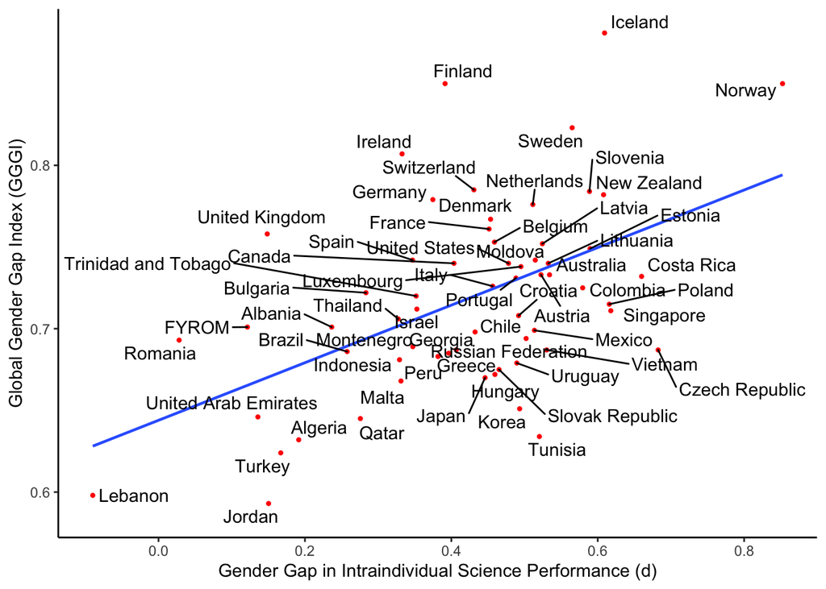

```r
## plot
ggplot(tmp, aes(y = GGI, x = scieGap)) +
  geom_point(color = "red", size = 0.8) +
  geom_smooth(method = "lm", fill = NA, size = 0.8) +
  geom_text_repel(aes(label = country)) +
  labs(y = "Global Gender Gap Index (GGGI)", x = "Gender Gap in Intraindividual Science Performance (d)") +
  theme_classic()
```

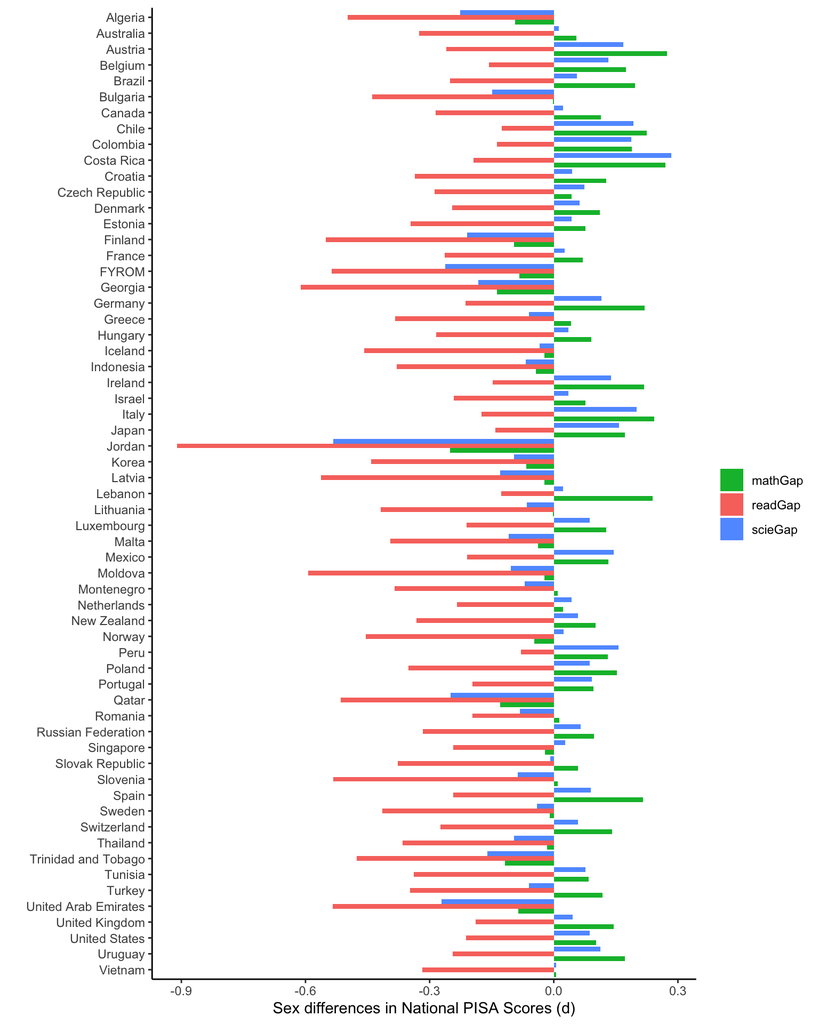

```r
## Panel A
cdat.n.cohend <- dat.s %>% group_by(country) %>%
  dplyr::summarize(

    scieGap = cohens_d(scie[gender == "Male"], scie[gender == "Female"]),
    mathGap = cohens_d(math[gender == "Male"], math[gender == "Female"]),
    readGap = cohens_d(read[gender == "Male"], read[gender == "Female"]),
    efficacyGap = cohens_d(efficacy[gender == "Male"], efficacy[gender == "Female"])

  ) %>%
  left_join(., cdat , by = "country")

cdat.n.cohend.long <- cdat.n.cohend %>%
  na.omit() %>%
  gather(scieGap:readGap,key = "gap_type", value = "gap")


ggplot(cdat.n.cohend.long, aes(x = reorder(country, desc(country)), y = gap, fill = gap_type)) +
  geom_bar(stat = "identity", position = "dodge") +
  scale_fill_manual(values=c("#00BA38", "#F8766D", "#619CFF")) +
  coord_flip() +
  labs(x = "", y = "Sex differences in National PISA Scores (d)",
       fill = "") +
  theme_classic()
```

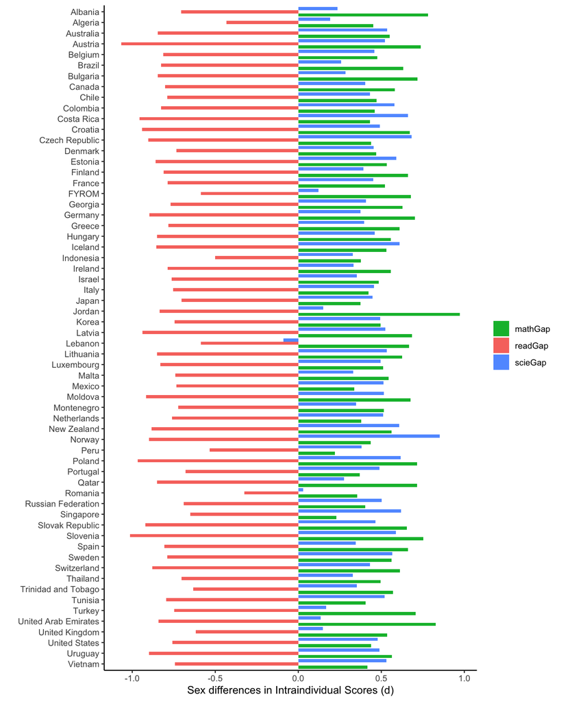

```r
## Panel B
cdat.n.long <- gather(na.omit(cdat.n), scieGap:readGap,key = "gap_type", value = "gap")

ggplot(cdat.n.long, aes(x = reorder(country, desc(country)), y = gap, fill = gap_type)) +
  geom_bar(stat = "identity", position = "dodge") +
  scale_fill_manual(values=c("#00BA38", "#F8766D", "#619CFF")) +
  coord_flip() +
  labs(x = "", y = "Sex differences in Intraindividual Scores (d)",
       fill = "") +
  theme_classic()
```

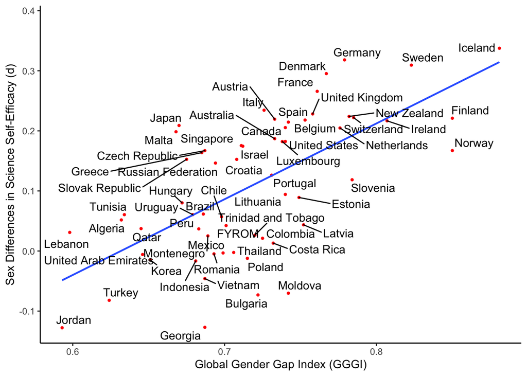

```r
ggplot(cdat.n.cohend, aes(x = GGI, y = efficacyGap)) +
  geom_point(color = "red", size = 0.8) +
  geom_smooth(method = "lm", fill = NA, size = 0.8) +
  geom_text_repel(aes(label = country)) +
  labs(x = "Global Gender Gap Index (GGGI)", y = "Sex Differences in Science Self-Efficacy (d)") +
  theme_classic()
```